# R Notebook

## Objective:

The primary objective of this project is to leverage machine learning techniques and data analysis to predict the risk of heart attacks. By analyzing a comprehensive dataset containing various health and lifestyle parameters, we aim to develop a predictive model that can accurately identify individuals at high risk of experiencing a heart attack. This project seeks to explore the following research questions:

**Predictive Power**: Can machine learning algorithms effectively predict the risk of heart attacks based on the provided dataset?

**Feature Importance**: Which health and lifestyle factors contribute most significantly to the prediction of heart attack risk?

**Model Comparison**: Which machine learning models (e.g., decision trees, random forests, logistic regression, neural networks) perform best in terms of accuracy, precision, recall, and other relevant metrics?

**Data Insights**: What patterns and insights can be derived from the dataset regarding the prevalence and risk factors associated with heart attacks?

```r
library(tidyverse)
library(dplyr)
library(randomForest)
library(ggplot2)
library(tidyverse, warn.conflicts=FALSE)
library(naivebayes, warn.conflicts=FALSE)
library(rpart, warn.conflicts=FALSE)
library(randomForest, warn.conflicts=FALSE)
library(yardstick, warn.conflicts=FALSE)
library(rsample, warn.conflicts=FALSE)
```

## Data Source:

The data source is from: https://www.kaggle.com/datasets/iamsouravbanerjee/heart-attack-prediction-dataset

## Original Format:

CSV FIle

## LOad the Data

```r
# Load the dataset
data = read.csv("C:/Users/sansk/OneDrive/Desktop/heart_attack_prediction_dataset.csv")

# Inspect the first few rows of the dataset
print("First few rows of the dataset:")
```

```
[1] "First few rows of the dataset:"
```

```r
head(data)
```

|  | Patient.ID | Age | Sex | Cholesterol | Blood.Pressure | Heart.Rate | Diabetes | Family.History | Smoking | Obesity | Alcohol.Consumption | Exercise.Hours.Per.Week | Diet | Previous.Heart.Problems | Medication.Use | Stress.Level | Sedentary.Hours.Per.Day | Income | BMI | Triglycerides | Physical.Activity.Days.Per.Week | Sleep.Hours.Per.Day | Country | Continent | Hemisphere | Heart.Attack.Risk |
| --- | --- | --- | --- | --- | --- | --- | --- | --- | --- | --- | --- | --- | --- | --- | --- | --- | --- | --- | --- | --- | --- | --- | --- | --- | --- | --- |
| 1 | BMW7812 | 67 | Male | 208 | 158/88 | 72 | 0 | 0 | 1 | 0 | 0 | 4.168189 | Average | 0 | 0 | 9 | 6.615001 | 261404 | 31.25123 | 286 | 0 | 6 | Argentina | South America | Southern Hemisphere | 0 |
| 2 | CZE1114 | 21 | Male | 389 | 165/93 | 98 | 1 | 1 | 1 | 1 | 1 | 1.813242 | Unhealthy | 1 | 0 | 1 | 4.963459 | 285768 | 27.19497 | 235 | 1 | 7 | Canada | North America | Northern Hemisphere | 0 |
| 3 | BNI9906 | 21 | Female | 324 | 174/99 | 72 | 1 | 0 | 0 | 0 | 0 | 2.078353 | Healthy | 1 | 1 | 9 | 9.463426 | 235282 | 28.17657 | 587 | 4 | 4 | France | Europe | Northern Hemisphere | 0 |
| 4 | JLN3497 | 84 | Male | 383 | 163/100 | 73 | 1 | 1 | 1 | 0 | 1 | 9.828130 | Average | 1 | 0 | 9 | 7.648981 | 125640 | 36.46470 | 378 | 3 | 4 | Canada | North America | Northern Hemisphere | 0 |
| 5 | GFO8847 | 66 | Male | 318 | 91/88 | 93 | 1 | 1 | 1 | 1 | 0 | 5.804299 | Unhealthy | 1 | 0 | 6 | 1.514821 | 160555 | 21.80914 | 231 | 1 | 5 | Thailand | Asia | Northern Hemisphere | 0 |
| 6 | ZOO7941 | 54 | Female | 297 | 172/86 | 48 | 1 | 1 | 1 | 0 | 1 | 0.625008 | Unhealthy | 1 | 1 | 2 | 7.798752 | 241339 | 20.14684 | 795 | 5 | 10 | Germany | Europe | Northern Hemisphere | 1 |

## Summary Statistics

```r
print("Summary statistics of the dataset:")
```

```
[1] "Summary statistics of the dataset:"
```

```r
summary(data)
```

```
  Patient.ID             Age            Sex             Cholesterol    Blood.Pressure       Heart.Rate        Diabetes
 Length:8763        Min.   :18.00   Length:8763        Min.   :120.0   Length:8763        Min.   : 40.00   Min.   :0.0000
 Class :character   1st Qu.:35.00   Class :character   1st Qu.:192.0   Class :character   1st Qu.: 57.00   1st Qu.:0.0000
 Mode  :character   Median :54.00   Mode  :character   Median :259.0   Mode  :character   Median : 75.00   Median :1.0000
                    Mean   :53.71                      Mean   :259.9                      Mean   : 75.02   Mean   :0.6523
                    3rd Qu.:72.00                      3rd Qu.:330.0                      3rd Qu.: 93.00   3rd Qu.:1.0000
                    Max.   :90.00                      Max.   :400.0                      Max.   :110.00   Max.   :1.0000
 Family.History     Smoking          Obesity       Alcohol.Consumption Exercise.Hours.Per.Week     Diet
 Min.   :0.000   Min.   :0.0000   Min.   :0.0000   Min.   :0.0000      Min.   : 0.002442       Length:8763
 1st Qu.:0.000   1st Qu.:1.0000   1st Qu.:0.0000   1st Qu.:0.0000      1st Qu.: 4.981579       Class :character
 Median :0.000   Median :1.0000   Median :1.0000   Median :1.0000      Median :10.069559       Mode  :character
 Mean   :0.493   Mean   :0.8968   Mean   :0.5014   Mean   :0.5981      Mean   :10.014284
 3rd Qu.:1.000   3rd Qu.:1.0000   3rd Qu.:1.0000   3rd Qu.:1.0000      3rd Qu.:15.050018
 Max.   :1.000   Max.   :1.0000   Max.   :1.0000   Max.   :1.0000      Max.   :19.998709
 Previous.Heart.Problems Medication.Use    Stress.Level   Sedentary.Hours.Per.Day     Income            BMI
 Min.   :0.0000          Min.   :0.0000   Min.   : 1.00   Min.   : 0.001263       Min.   : 20062   Min.   :18.00
 1st Qu.:0.0000          1st Qu.:0.0000   1st Qu.: 3.00   1st Qu.: 2.998794       1st Qu.: 88310   1st Qu.:23.42
 Median :0.0000          Median :0.0000   Median : 5.00   Median : 5.933622       Median :157866   Median :28.77
 Mean   :0.4958          Mean   :0.4983   Mean   : 5.47   Mean   : 5.993690       Mean   :158263   Mean   :28.89
 3rd Qu.:1.0000          3rd Qu.:1.0000   3rd Qu.: 8.00   3rd Qu.: 9.019124       3rd Qu.:227749   3rd Qu.:34.32
 Max.   :1.0000          Max.   :1.0000   Max.   :10.00   Max.   :11.999313       Max.   :299954   Max.   :40.00
 Triglycerides   Physical.Activity.Days.Per.Week Sleep.Hours.Per.Day   Country           Continent          Hemisphere
 Min.   : 30.0   Min.   :0.00                    Min.   : 4.000      Length:8763        Length:8763        Length:8763
 1st Qu.:225.5   1st Qu.:2.00                    1st Qu.: 5.000      Class :character   Class :character   Class :character
 Median :417.0   Median :3.00                    Median : 7.000      Mode  :character   Mode  :character   Mode  :character
 Mean   :417.7   Mean   :3.49                    Mean   : 7.024
 3rd Qu.:612.0   3rd Qu.:5.00                    3rd Qu.: 9.000
 Max.   :800.0   Max.   :7.00                    Max.   :10.000
 Heart.Attack.Risk
 Min.   :0.0000
 1st Qu.:0.0000
 Median :0.0000
 Mean   :0.3582
 3rd Qu.:1.0000
 Max.   :1.0000
```

Handle any missing values:

```r
# Check for missing values
print("Count of missing values in each column:")
```

```
[1] "Count of missing values in each column:"
```

```r
missing_values <- colSums(is.na(data))
print(missing_values)
```

```
                     Patient.ID                             Age                             Sex
                              0                               0                               0
                    Cholesterol                  Blood.Pressure                      Heart.Rate
                              0                               0                               0
                       Diabetes                  Family.History                         Smoking
                              0                               0                               0
                        Obesity             Alcohol.Consumption         Exercise.Hours.Per.Week
                              0                               0                               0
                           Diet         Previous.Heart.Problems                  Medication.Use
                              0                               0                               0
                   Stress.Level         Sedentary.Hours.Per.Day                          Income
                              0                               0                               0
                            BMI                   Triglycerides Physical.Activity.Days.Per.Week
                              0                               0                               0
            Sleep.Hours.Per.Day                         Country                       Continent
                              0                               0                               0
                     Hemisphere               Heart.Attack.Risk
                              0                               0
```

Fill in Missing Values with mean (continuous):

```r
data <- data %>%
  mutate_if(is.numeric, ~ ifelse(is.na(.), mean(., na.rm = TRUE), .))
```

Fill in mode for categorical features:

```r
# function to get the mode
get_mode <- function(v) {
  uniqv <- unique(v)
  uniqv[which.max(tabulate(match(v, uniqv)))]
}

# Apply the function to fill missing values
data <- data %>%
  mutate_if(is.factor, ~ ifelse(is.na(.), get_mode(.), .))
```

Check For Duplicates:

```r
# Check for duplicates
duplicates <- data[duplicated(data), ]
print("Duplicate rows in the dataset:")
```

```
[1] "Duplicate rows in the dataset:"
```

```r
print(duplicates)
```

| Patient.ID | Age | Sex | Cholesterol | Blood.Pressure | Heart.Rate | Diabetes | Family.History | Smoking | Obesity | Alcohol.Consumption | Exercise.Hours.Per.Week | Diet | Previous.Heart.Problems | Medication.Use | Stress.Level | Sedentary.Hours.Per.Day | Income | BMI | Triglycerides | Physical.Activity.Days.Per.Week | Sleep.Hours.Per.Day | Country | Continent | Hemisphere | Heart.Attack.Risk |
| --- | --- | --- | --- | --- | --- | --- | --- | --- | --- | --- | --- | --- | --- | --- | --- | --- | --- | --- | --- | --- | --- | --- | --- | --- | --- |

```r
# Display the structure of the dataset
print("Structure of the dataset:")
```

```
[1] "Structure of the dataset:"
```

```r
str(data)
```

```
'data.frame':   8763 obs. of  26 variables:
 $ Patient.ID                     : chr  "BMW7812" "CZE1114" "BNI9906" "JLN3497" ...
 $ Age                            : int  67 21 21 84 66 54 90 84 20 43 ...
 $ Sex                            : chr  "Male" "Male" "Female" "Male" ...
 $ Cholesterol                    : int  208 389 324 383 318 297 358 220 145 248 ...
 $ Blood.Pressure                 : chr  "158/88" "165/93" "174/99" "163/100" ...
 $ Heart.Rate                     : int  72 98 72 73 93 48 84 107 68 55 ...
 $ Diabetes                       : int  0 1 1 1 1 1 0 0 1 0 ...
 $ Family.History                 : int  0 1 0 1 1 1 0 0 0 1 ...
 $ Smoking                        : int  1 1 0 1 1 1 1 1 1 1 ...
 $ Obesity                        : int  0 1 0 0 1 0 0 1 1 1 ...
 $ Alcohol.Consumption            : int  0 1 0 1 0 1 1 1 0 1 ...
 $ Exercise.Hours.Per.Week        : num  4.17 1.81 2.08 9.83 5.8 ...
 $ Diet                           : chr  "Average" "Unhealthy" "Healthy" "Average" ...
 $ Previous.Heart.Problems        : int  0 1 1 1 1 1 0 0 0 0 ...
 $ Medication.Use                 : int  0 0 1 0 0 1 0 1 0 0 ...
 $ Stress.Level                   : int  9 1 9 9 6 2 7 4 5 4 ...
 $ Sedentary.Hours.Per.Day        : num  6.62 4.96 9.46 7.65 1.51 ...
 $ Income                         : int  261404 285768 235282 125640 160555 241339 190450 122093 25086 209703 ...
 $ BMI                            : num  31.3 27.2 28.2 36.5 21.8 ...
 $ Triglycerides                  : int  286 235 587 378 231 795 284 370 790 232 ...
 $ Physical.Activity.Days.Per.Week: int  0 1 4 3 1 5 4 6 7 7 ...
 $ Sleep.Hours.Per.Day            : int  6 7 4 4 5 10 10 7 4 7 ...
 $ Country                        : chr  "Argentina" "Canada" "France" "Canada" ...
 $ Continent                      : chr  "South America" "North America" "Europe" "North America" ...
 $ Hemisphere                     : chr  "Southern Hemisphere" "Northern Hemisphere" "Northern Hemisphere" "Northern Hemisphere" ...
 $ Heart.Attack.Risk              : int  0 0 0 0 0 1 1 1 0 0 ...
```

## Data Content:

Number of Rows: **8,763**

Number of Columns: **26**

## Relevant Variables:

**Patient ID**: Unique identifier for each patient.

**Age**: Age of the patient.

**Sex**: Gender of the patient (Male/Female).

**Cholesterol**: Cholesterol level in mg/dL.

**Blood Pressure**: Blood pressure reading (systolic/diastolic).

**Heart Rate**: Heart rate in beats per minute.

**Diabetes**: Presence of diabetes (0 = No, 1 = Yes).

**Family History**: Family history of heart disease (0 = No, 1 = Yes).

**Smoking**: Smoking status (0 = No, 1 = Yes).

**Obesity**: Obesity status (0 = No, 1 = Yes).

**Alcohol Consumption**: Frequency of alcohol consumption.

**Exercise Hours Per Week**: Average hours of exercise per week.

**Previous Heart Problems**: History of heart problems (0 = No, 1 = Yes).

**Medication Use**: Use of medication (0 = No, 1 = Yes).

**Stress Level**: Perceived stress level.

**Sedentary Hours Per Day**: Average hours spent sedentary per day.

**Income**: Annual income in USD.

**BMI**: Body Mass Index.

**Triglycerides**: Triglyceride level in mg/dL.

**Physical Activity Days Per Week**: Number of days of physical activity per week.

**Sleep Hours Per Day**: Average hours of sleep per day.

**Country**: Country of residence.

**Continent**: Continent of residence.

**Hemisphere**: Hemisphere of residence.

**Heart Attack Risk**: Risk of heart attack (0 = No, 1 = Yes).

## Data Transformation:

```r
# Data Transformation: Encoding Categorical Variables
data$Sex <- ifelse(data$Sex == "Male", 1, 0)
data$Diet <- factor(data$Diet)
data$Country <- factor(data$Country)
data$Continent <- factor(data$Continent)
data$Hemisphere <- factor(data$Hemisphere)
```

## Data Visualization:

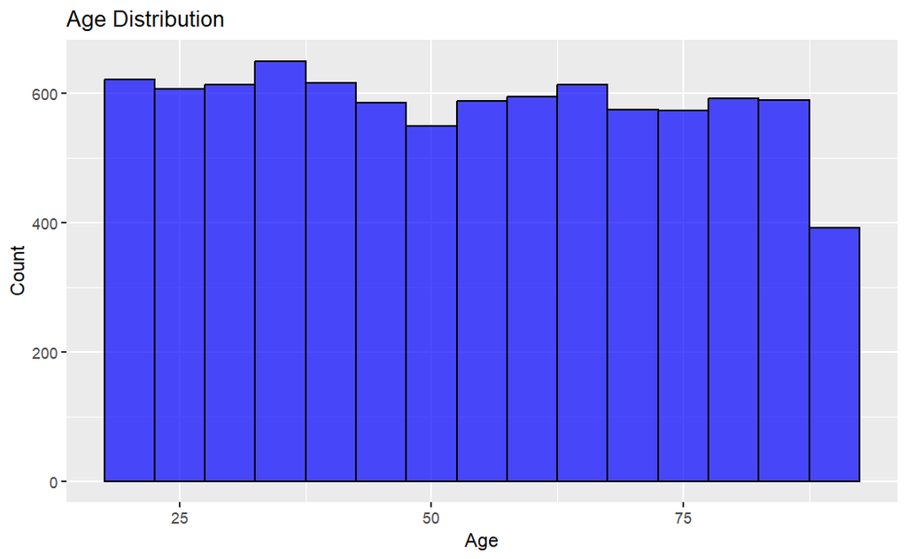

```r
# Age distribution
ggplot(data, aes(x=Age)) +
  geom_histogram(binwidth=5, fill="blue", color="black", alpha=0.7) +
  labs(title="Age Distribution", x="Age", y="Count")
```

```r
# Basic statistics for Age
age_summary <- summary(data$Age)
age_mean <- mean(data$Age)
age_median <- median(data$Age)
age_sd <- sd(data$Age)

print("Age Summary:")
```

```
[1] "Age Summary:"
```

```r
print(age_summary)
```

```
   Min. 1st Qu.  Median    Mean 3rd Qu.    Max.
  18.00   35.00   54.00   53.71   72.00   90.00
```

```r
print(paste("Mean Age:", age_mean))
```

```
[1] "Mean Age: 53.7079767203013"
```

```r
print(paste("Median Age:", age_median))
```

```
[1] "Median Age: 54"
```

```r
print(paste("Standard Deviation of Age:", age_sd))
```

```
[1] "Standard Deviation of Age: 21.249508802216"
```

**Age Summary:**

**Central Tendency**: The mean and median ages are quite close, suggesting that the age distribution is fairly symmetric around the central values.

**Spread**: The wide range between the minimum (18 years) and maximum (90 years) ages, along with the substantial standard deviation (21.25 years), indicates significant variability in the ages of individuals in the dataset.

**Quartiles**: The 1st and 3rd quartiles provide a sense of the middle 50% of the data, ranging from 35 to 72 years, which shows that half of the individuals are within this age range. This age distribution suggests that the dataset includes a broad spectrum of ages, with a central tendency around middle age (approximately 54 years).

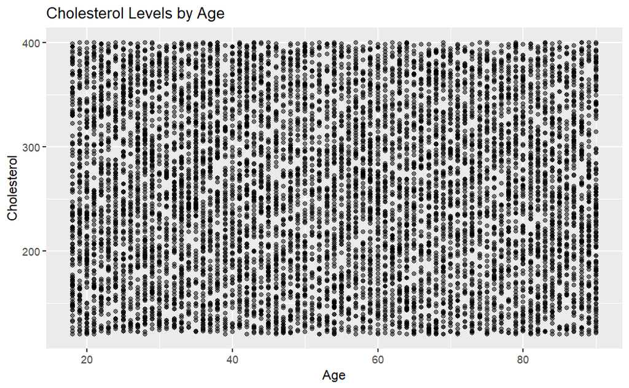

```r
# Cholesterol levels by Age
ggplot(data, aes(x=Age, y=Cholesterol)) +
  geom_point(alpha=0.5) +
  labs(title="Cholesterol Levels by Age", x="Age", y="Cholesterol")
```

```r
# Basic statistics for Cholesterol
cholesterol_summary <- summary(data$Cholesterol)
cholesterol_mean <- mean(data$Cholesterol)
cholesterol_median <- median(data$Cholesterol)
cholesterol_sd <- sd(data$Cholesterol)

print("Cholesterol Summary:")
```

```
[1] "Cholesterol Summary:"
```

```r
print(cholesterol_summary)
```

```
   Min. 1st Qu.  Median    Mean 3rd Qu.    Max.
  120.0   192.0   259.0   259.9   330.0   400.0
```

```r
print(paste("Mean Cholesterol:", cholesterol_mean))
```

```
[1] "Mean Cholesterol: 259.877211000799"
```

```r
print(paste("Median Cholesterol:", cholesterol_median))
```

```
[1] "Median Cholesterol: 259"
```

```r
print(paste("Standard Deviation of Cholesterol:", cholesterol_sd))
```

```
[1] "Standard Deviation of Cholesterol: 80.8632761047705"
```

```r
# Cholesterol statistics by age group
cholesterol_by_age <- data %>%
  group_by(Age) %>%
  summarize(mean_cholesterol = mean(Cholesterol),
            median_cholesterol = median(Cholesterol),
            sd_cholesterol = sd(Cholesterol))

print("Cholesterol Statistics by Age Group:")
```

```
[1] "Cholesterol Statistics by Age Group:"
```

```r
print(cholesterol_by_age)
```

| Age | mean_cholesterol | median_cholesterol | sd_cholesterol |
| --- | --- | --- | --- |
| 18 | 254.1626 | 236.0 | 86.23646 |
| 19 | 254.5234 | 253.0 | 79.15508 |
| 20 | 248.7462 | 236.5 | 81.89266 |
| 21 | 259.5641 | 252.0 | 84.39178 |
| 22 | 271.2258 | 278.5 | 82.95780 |
| 23 | 261.2778 | 255.0 | 82.38828 |
| 24 | 262.9538 | 263.5 | 76.73996 |
| 25 | 261.3712 | 257.0 | 84.35923 |
| 26 | 263.9643 | 253.5 | 83.51791 |
| 27 | 267.6160 | 275.0 | 80.55381 |

[output cut: 63 more lines]

```r
NA
```

**Cholesterol summary:**

**Central Tendency**: The mean and median cholesterol levels are very close, both around 259 mg/dL, indicating a symmetric distribution centered around this value.

**Spread**: The range of cholesterol levels is from 120 mg/dL to 400 mg/dL, with a standard deviation of 80.86 mg/dL, suggesting a significant variation in cholesterol levels across individuals.

**Quartiles**: The 1st and 3rd quartiles (192 mg/dL and 330 mg/dL, respectively) indicate that the middle 50% of the data lies within this range.

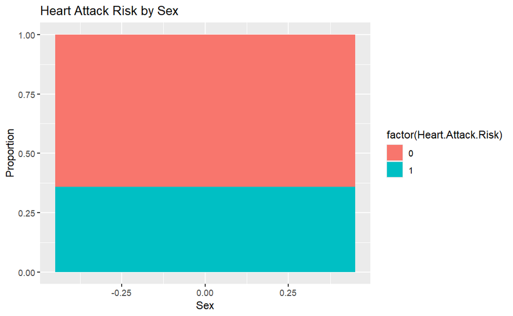

```r
# Heart Attack Risk by various factors
ggplot(data, aes(x=Sex, fill=factor(Heart.Attack.Risk))) +
  geom_bar(position="fill") +
  labs(title="Heart Attack Risk by Sex", x="Sex", y="Proportion")
```

**Heart Attack risk by sex:**

```r
# Proportion of Heart Attack Risk by Sex
heart_attack_by_sex <- data %>%
  group_by(Sex, Heart.Attack.Risk) %>%
  summarise(count = n(), .groups = 'drop') %>%
  mutate(proportion = count / sum(count))


print(heart_attack_by_sex)
```

| Sex | Heart.Attack.Risk | count | proportion |
| --- | --- | --- | --- |
| 0 | 0 | 5624 | 0.6417893 |
| 0 | 1 | 3139 | 0.3582107 |

```r
NA
```

**Heart Attack by sex summary**:

**Insights**:

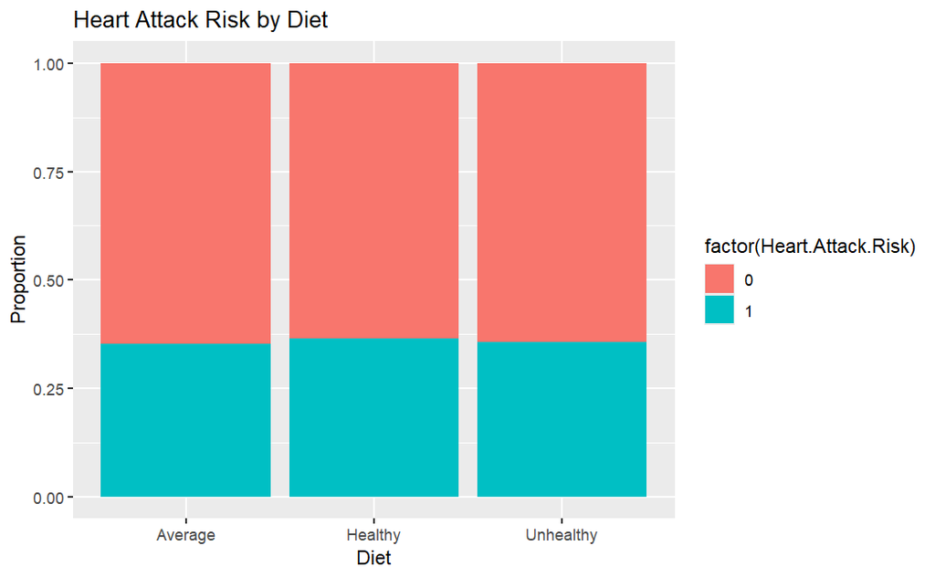

```r
ggplot(data, aes(x=Diet, fill=factor(Heart.Attack.Risk))) +
  geom_bar(position="fill") +
  labs(title="Heart Attack Risk by Diet", x="Diet", y="Proportion")
```

```r
# Proportion of Heart Attack Risk by Diet
heart_attack_by_diet <- data %>%
  group_by(Diet, Heart.Attack.Risk) %>%
  summarise(count = n(), .groups = 'drop') %>%
  mutate(proportion = count / sum(count))

print(heart_attack_by_diet)
```

| Diet | Heart.Attack.Risk | count | proportion |
| --- | --- | --- | --- |
| Average | 0 | 1886 | 0.2152231 |
| Average | 1 | 1026 | 0.1170832 |
| Healthy | 0 | 1881 | 0.2146525 |
| Healthy | 1 | 1079 | 0.1231313 |
| Unhealthy | 0 | 1857 | 0.2119137 |
| Unhealthy | 1 | 1034 | 0.1179961 |

```r
NA
```

**Summary Heart Attack Risk by Diet:**

**Diet Distribution:** The counts of individuals with each type of diet are relatively similar, suggesting a balanced representation across different dietary habits.

## Modeling and Results

First, the data is cleaned up and subsequently trained for prediction.

```r
data = data %>%
  mutate(Outcome = Heart.Attack.Risk)
glimpse(data)
```

```
Rows: 8,763
Columns: 27
$ Patient.ID                      <chr> "BMW7812", "CZE1114", "BNI9906", "JLN3497", "GFO8847", "ZOO7941", "WYV0966", "XXM097…
$ Age                             <int> 67, 21, 21, 84, 66, 54, 90, 84, 20, 43, 73, 71, 77, 60, 88, 73, 69, 38, 50, 60, 66, …
$ Sex                             <dbl> 0, 0, 0, 0, 0, 0, 0, 0, 0, 0, 0, 0, 0, 0, 0, 0, 0, 0, 0, 0, 0, 0, 0, 0, 0, 0, 0, 0, …
$ Cholesterol                     <int> 208, 389, 324, 383, 318, 297, 358, 220, 145, 248, 373, 374, 228, 259, 297, 122, 379,…
$ Blood.Pressure                  <chr> "158/88", "165/93", "174/99", "163/100", "91/88", "172/86", "102/73", "131/68", "144…
$ Heart.Rate                      <int> 72, 98, 72, 73, 93, 48, 84, 107, 68, 55, 97, 70, 68, 85, 102, 97, 40, 56, 104, 71, 6…
$ Diabetes                        <int> 0, 1, 1, 1, 1, 1, 0, 0, 1, 0, 1, 1, 1, 1, 1, 1, 1, 1, 1, 1, 1, 0, 0, 1, 1, 0, 0, 0, …
$ Family.History                  <int> 0, 1, 0, 1, 1, 1, 0, 0, 0, 1, 1, 1, 1, 1, 1, 1, 1, 0, 0, 0, 0, 0, 1, 1, 0, 0, 1, 0, …
$ Smoking                         <int> 1, 1, 0, 1, 1, 1, 1, 1, 1, 1, 1, 1, 1, 1, 1, 1, 1, 1, 1, 1, 1, 1, 1, 1, 1, 1, 1, 1, …
$ Obesity                         <int> 0, 1, 0, 0, 1, 0, 0, 1, 1, 1, 0, 1, 1, 0, 0, 0, 1, 1, 0, 0, 1, 1, 0, 0, 1, 0, 0, 1, …
$ Alcohol.Consumption             <int> 0, 1, 0, 1, 0, 1, 1, 1, 0, 1, 1, 1, 1, 1, 1, 1, 1, 0, 1, 1, 0, 1, 1, 1, 1, 1, 1, 1, …
$ Exercise.Hours.Per.Week         <dbl> 4.1681888, 1.8132416, 2.0783530, 9.8281296, 5.8042988, 0.6250080, 4.0981771, 3.42792…
$ Diet                            <fct> Average, Unhealthy, Healthy, Average, Unhealthy, Unhealthy, Healthy, Average, Averag…
$ Previous.Heart.Problems         <int> 0, 1, 1, 1, 1, 1, 0, 0, 0, 0, 1, 0, 0, 1, 0, 0, 1, 0, 1, 1, 1, 0, 1, 1, 1, 0, 1, 1, …
$ Medication.Use                  <int> 0, 0, 1, 0, 0, 1, 0, 1, 0, 0, 1, 0, 0, 1, 1, 0, 0, 1, 1, 0, 1, 0, 0, 0, 0, 1, 0, 1, …
$ Stress.Level                    <int> 9, 1, 9, 9, 6, 2, 7, 4, 5, 4, 8, 4, 9, 1, 2, 5, 5, 9, 1, 8, 1, 9, 2, 7, 10, 2, 4, 4,…
$ Sedentary.Hours.Per.Day         <dbl> 6.615001, 4.963459, 9.463426, 7.648981, 1.514821, 7.798752, 0.627356, 10.543780, 11.…
$ Income                          <int> 261404, 285768, 235282, 125640, 160555, 241339, 190450, 122093, 25086, 209703, 50030…
$ BMI                             <dbl> 31.25123, 27.19497, 28.17657, 36.46470, 21.80914, 20.14684, 28.88581, 22.22186, 35.8…
$ Triglycerides                   <int> 286, 235, 587, 378, 231, 795, 284, 370, 790, 232, 469, 523, 590, 506, 635, 773, 68, …
$ Physical.Activity.Days.Per.Week <int> 0, 1, 4, 3, 1, 5, 4, 6, 7, 7, 0, 4, 7, 1, 3, 5, 3, 0, 1, 7, 1, 4, 4, 0, 5, 4, 3, 4, …
$ Sleep.Hours.Per.Day             <int> 6, 7, 4, 4, 5, 10, 10, 7, 4, 7, 4, 8, 6, 4, 6, 8, 6, 6, 5, 7, 10, 6, 8, 9, 10, 5, 8,…
$ Country                         <fct> Argentina, Canada, France, Canada, Thailand, Germany, Canada, Japan, Brazil, Japan, …
$ Continent                       <fct> South America, North America, Europe, North America, Asia, Europe, North America, As…
$ Hemisphere                      <fct> Southern Hemisphere, Northern Hemisphere, Northern Hemisphere, Northern Hemisphere, …
$ Heart.Attack.Risk               <int> 0, 0, 0, 0, 0, 1, 1, 1, 0, 0, 0, 0, 1, 1, 0, 1, 0, 0, 1, 0, 0, 1, 0, 0, 0, 0, 0, 0, …
$ Outcome                         <int> 0, 0, 0, 0, 0, 1, 1, 1, 0, 0, 0, 0, 1, 1, 0, 1, 0, 0, 1, 0, 0, 1, 0, 0, 0, 0, 0, 0, …
```

Created a new row, called ‘Outcome’, that will correlate to the ‘Heart Attack Risk’ column. ‘0’ is now known as ‘NotatRisk’, and ‘1’ is known as ‘AtRisk’.

```r
data = data %>%
  mutate(Outcome = as.factor(if_else(as.logical(Outcome), "AtRisk", "NotatRisk")))
glimpse(data)
```

```
Rows: 8,763
Columns: 27
$ Patient.ID                      <chr> "BMW7812", "CZE1114", "BNI9906", "JLN3497", "GFO8847", "ZOO7941", "WYV0966", "XXM097…
$ Age                             <int> 67, 21, 21, 84, 66, 54, 90, 84, 20, 43, 73, 71, 77, 60, 88, 73, 69, 38, 50, 60, 66, …
$ Sex                             <dbl> 0, 0, 0, 0, 0, 0, 0, 0, 0, 0, 0, 0, 0, 0, 0, 0, 0, 0, 0, 0, 0, 0, 0, 0, 0, 0, 0, 0, …
$ Cholesterol                     <int> 208, 389, 324, 383, 318, 297, 358, 220, 145, 248, 373, 374, 228, 259, 297, 122, 379,…
$ Blood.Pressure                  <chr> "158/88", "165/93", "174/99", "163/100", "91/88", "172/86", "102/73", "131/68", "144…
$ Heart.Rate                      <int> 72, 98, 72, 73, 93, 48, 84, 107, 68, 55, 97, 70, 68, 85, 102, 97, 40, 56, 104, 71, 6…
$ Diabetes                        <int> 0, 1, 1, 1, 1, 1, 0, 0, 1, 0, 1, 1, 1, 1, 1, 1, 1, 1, 1, 1, 1, 0, 0, 1, 1, 0, 0, 0, …
$ Family.History                  <int> 0, 1, 0, 1, 1, 1, 0, 0, 0, 1, 1, 1, 1, 1, 1, 1, 1, 0, 0, 0, 0, 0, 1, 1, 0, 0, 1, 0, …
$ Smoking                         <int> 1, 1, 0, 1, 1, 1, 1, 1, 1, 1, 1, 1, 1, 1, 1, 1, 1, 1, 1, 1, 1, 1, 1, 1, 1, 1, 1, 1, …
$ Obesity                         <int> 0, 1, 0, 0, 1, 0, 0, 1, 1, 1, 0, 1, 1, 0, 0, 0, 1, 1, 0, 0, 1, 1, 0, 0, 1, 0, 0, 1, …
$ Alcohol.Consumption             <int> 0, 1, 0, 1, 0, 1, 1, 1, 0, 1, 1, 1, 1, 1, 1, 1, 1, 0, 1, 1, 0, 1, 1, 1, 1, 1, 1, 1, …
$ Exercise.Hours.Per.Week         <dbl> 4.1681888, 1.8132416, 2.0783530, 9.8281296, 5.8042988, 0.6250080, 4.0981771, 3.42792…
$ Diet                            <fct> Average, Unhealthy, Healthy, Average, Unhealthy, Unhealthy, Healthy, Average, Averag…
$ Previous.Heart.Problems         <int> 0, 1, 1, 1, 1, 1, 0, 0, 0, 0, 1, 0, 0, 1, 0, 0, 1, 0, 1, 1, 1, 0, 1, 1, 1, 0, 1, 1, …
$ Medication.Use                  <int> 0, 0, 1, 0, 0, 1, 0, 1, 0, 0, 1, 0, 0, 1, 1, 0, 0, 1, 1, 0, 1, 0, 0, 0, 0, 1, 0, 1, …
$ Stress.Level                    <int> 9, 1, 9, 9, 6, 2, 7, 4, 5, 4, 8, 4, 9, 1, 2, 5, 5, 9, 1, 8, 1, 9, 2, 7, 10, 2, 4, 4,…
$ Sedentary.Hours.Per.Day         <dbl> 6.615001, 4.963459, 9.463426, 7.648981, 1.514821, 7.798752, 0.627356, 10.543780, 11.…
$ Income                          <int> 261404, 285768, 235282, 125640, 160555, 241339, 190450, 122093, 25086, 209703, 50030…
$ BMI                             <dbl> 31.25123, 27.19497, 28.17657, 36.46470, 21.80914, 20.14684, 28.88581, 22.22186, 35.8…
$ Triglycerides                   <int> 286, 235, 587, 378, 231, 795, 284, 370, 790, 232, 469, 523, 590, 506, 635, 773, 68, …
$ Physical.Activity.Days.Per.Week <int> 0, 1, 4, 3, 1, 5, 4, 6, 7, 7, 0, 4, 7, 1, 3, 5, 3, 0, 1, 7, 1, 4, 4, 0, 5, 4, 3, 4, …
$ Sleep.Hours.Per.Day             <int> 6, 7, 4, 4, 5, 10, 10, 7, 4, 7, 4, 8, 6, 4, 6, 8, 6, 6, 5, 7, 10, 6, 8, 9, 10, 5, 8,…
$ Country                         <fct> Argentina, Canada, France, Canada, Thailand, Germany, Canada, Japan, Brazil, Japan, …
$ Continent                       <fct> South America, North America, Europe, North America, Asia, Europe, North America, As…
$ Hemisphere                      <fct> Southern Hemisphere, Northern Hemisphere, Northern Hemisphere, Northern Hemisphere, …
$ Heart.Attack.Risk               <int> 0, 0, 0, 0, 0, 1, 1, 1, 0, 0, 0, 0, 1, 1, 0, 1, 0, 0, 1, 0, 0, 1, 0, 0, 0, 0, 0, 0, …
$ Outcome                         <fct> NotatRisk, NotatRisk, NotatRisk, NotatRisk, NotatRisk, AtRisk, AtRisk, AtRisk, Notat…
```

The data was split into a 20% testing and 80% training set.

```r
split = initial_split(data, prop=.8)
train = training(split)
test = testing(split)
glimpse(train)
```

```
Rows: 7,010
Columns: 27
$ Patient.ID                      <chr> "GDA0387", "GBK2348", "CNZ6390", "KBI4457", "NSW1331", "TSV7524", "GIN1693", "WDW055…
$ Age                             <int> 87, 48, 59, 38, 53, 34, 21, 88, 73, 70, 56, 82, 46, 73, 52, 28, 23, 60, 56, 46, 44, …
$ Sex                             <dbl> 0, 0, 0, 0, 0, 0, 0, 0, 0, 0, 0, 0, 0, 0, 0, 0, 0, 0, 0, 0, 0, 0, 0, 0, 0, 0, 0, 0, …
$ Cholesterol                     <int> 140, 312, 232, 177, 124, 327, 395, 125, 332, 145, 386, 146, 396, 306, 205, 371, 308,…
$ Blood.Pressure                  <chr> "95/100", "172/90", "167/87", "104/63", "173/74", "130/86", "91/83", "178/100", "142…
$ Heart.Rate                      <int> 57, 67, 84, 68, 94, 96, 60, 45, 88, 90, 103, 86, 61, 86, 76, 76, 97, 49, 101, 64, 99…
$ Diabetes                        <int> 0, 0, 1, 0, 1, 0, 0, 0, 1, 0, 1, 0, 1, 1, 0, 0, 0, 0, 1, 0, 1, 0, 1, 0, 0, 1, 0, 1, …
$ Family.History                  <int> 1, 1, 1, 0, 1, 1, 0, 0, 0, 1, 1, 1, 0, 1, 1, 1, 0, 0, 0, 1, 0, 0, 1, 0, 0, 0, 0, 1, …
$ Smoking                         <int> 1, 1, 1, 1, 1, 1, 0, 1, 1, 1, 1, 1, 1, 1, 1, 0, 0, 1, 1, 1, 1, 1, 1, 1, 1, 1, 1, 1, …
$ Obesity                         <int> 0, 0, 0, 0, 0, 0, 0, 1, 0, 0, 1, 0, 0, 0, 1, 1, 0, 0, 1, 1, 1, 1, 1, 0, 0, 1, 0, 1, …
$ Alcohol.Consumption             <int> 1, 1, 0, 1, 0, 1, 1, 0, 0, 1, 0, 1, 1, 1, 1, 0, 0, 1, 0, 1, 1, 1, 1, 0, 0, 1, 1, 1, …
$ Exercise.Hours.Per.Week         <dbl> 7.05336084, 0.37565226, 0.51705952, 17.43710829, 6.00546684, 1.28252976, 2.48295097,…
$ Diet                            <fct> Unhealthy, Healthy, Average, Healthy, Average, Healthy, Unhealthy, Average, Average,…
$ Previous.Heart.Problems         <int> 1, 1, 0, 1, 0, 1, 1, 1, 0, 1, 1, 1, 1, 1, 1, 0, 1, 0, 1, 0, 1, 1, 0, 0, 1, 0, 1, 1, …
$ Medication.Use                  <int> 1, 1, 1, 0, 1, 1, 1, 1, 0, 0, 1, 0, 1, 1, 1, 1, 1, 1, 0, 0, 0, 1, 1, 1, 0, 1, 0, 1, …
$ Stress.Level                    <int> 7, 5, 2, 3, 5, 4, 10, 5, 10, 6, 10, 5, 9, 6, 2, 10, 8, 3, 3, 7, 1, 9, 8, 6, 8, 9, 5,…
$ Sedentary.Hours.Per.Day         <dbl> 5.18570319, 5.29141370, 9.76373079, 11.32840885, 5.42102140, 1.35903176, 7.51223111,…
$ Income                          <int> 83824, 175740, 246446, 131648, 122196, 219576, 45161, 202366, 246357, 201860, 93079,…
$ BMI                             <dbl> 26.04674, 20.23467, 25.21701, 32.37890, 38.72692, 28.52230, 30.14005, 29.73535, 34.1…
$ Triglycerides                   <int> 570, 663, 254, 349, 799, 113, 797, 264, 32, 97, 159, 369, 252, 106, 149, 726, 267, 3…
$ Physical.Activity.Days.Per.Week <int> 4, 0, 0, 7, 4, 5, 0, 4, 7, 2, 3, 7, 6, 6, 3, 0, 1, 6, 4, 3, 5, 7, 7, 6, 6, 1, 3, 6, …
$ Sleep.Hours.Per.Day             <int> 4, 6, 9, 7, 7, 9, 8, 7, 6, 8, 7, 5, 10, 5, 10, 7, 10, 8, 6, 8, 7, 7, 6, 8, 4, 8, 5, …
$ Country                         <fct> United Kingdom, United States, Argentina, Nigeria, Australia, Brazil, Argentina, Ind…
$ Continent                       <fct> Europe, North America, South America, Africa, Australia, South America, South Americ…
$ Hemisphere                      <fct> Northern Hemisphere, Northern Hemisphere, Southern Hemisphere, Northern Hemisphere, …
$ Heart.Attack.Risk               <int> 0, 1, 1, 0, 0, 0, 1, 0, 1, 1, 1, 0, 0, 0, 0, 0, 1, 1, 1, 0, 0, 0, 0, 0, 1, 0, 0, 0, …
$ Outcome                         <fct> NotatRisk, AtRisk, AtRisk, NotatRisk, NotatRisk, NotatRisk, AtRisk, NotatRisk, AtRis…
```

RANDOM FOREST MODEL

We chose factors relevant for prediction and then trained the model:

```r
set.seed(456)
mod.rf = randomForest(Outcome ~ Age + Sex + Cholesterol + Diet + Heart.Rate + Diabetes + Family.History + Smoking + Obesity + Exercise.Hours.Per.Week + Previous.Heart.Problems + Medication.Use + Stress.Level + BMI + Triglycerides + Physical.Activity.Days.Per.Week + Sleep.Hours.Per.Day, data = train, na.action = na.omit, importance = TRUE)
summary(mod.rf)
```

```
                Length Class  Mode
call                5  -none- call
type                1  -none- character
predicted        7010  factor numeric
err.rate         1500  -none- numeric
confusion           6  -none- numeric
votes           14020  matrix numeric
oob.times        7010  -none- numeric
classes             2  -none- character
importance         68  -none- numeric
importanceSD       51  -none- numeric
localImportance     0  -none- NULL
proximity           0  -none- NULL
ntree               1  -none- numeric
mtry                1  -none- numeric
forest             14  -none- list
y                7010  factor numeric
test                0  -none- NULL
inbag               0  -none- NULL
terms               3  terms  call
```

```r
rf.test = test %>%
  mutate(Prediction = predict(mod.rf, test, type="class"))
glimpse(rf.test)
```

```
Rows: 1,753
Columns: 28
$ Patient.ID                      <chr> "CZE1114", "BNI9906", "XXM0972", "FPS0415", "YYU9565", "VTW9069", "DCY3282", "RVN496…
$ Age                             <int> 21, 21, 84, 77, 60, 88, 73, 45, 90, 79, 86, 67, 29, 51, 70, 85, 67, 31, 24, 26, 31, …
$ Sex                             <dbl> 0, 0, 0, 0, 0, 0, 0, 0, 0, 0, 0, 0, 0, 0, 0, 0, 0, 0, 0, 0, 0, 0, 0, 0, 0, 0, 0, 0, …
$ Cholesterol                     <int> 389, 324, 220, 228, 259, 297, 122, 294, 159, 328, 375, 347, 129, 197, 279, 336, 222,…
$ Blood.Pressure                  <chr> "165/93", "174/99", "131/68", "101/72", "169/72", "112/81", "114/88", "130/84", "140…
$ Heart.Rate                      <int> 98, 72, 107, 68, 85, 102, 97, 66, 52, 74, 46, 65, 86, 79, 86, 73, 105, 92, 68, 46, 4…
$ Diabetes                        <int> 1, 1, 0, 1, 1, 1, 1, 0, 0, 0, 1, 1, 0, 1, 0, 1, 1, 1, 0, 1, 1, 1, 0, 1, 0, 1, 1, 1, …
$ Family.History                  <int> 1, 0, 0, 1, 1, 1, 1, 0, 0, 0, 1, 0, 1, 1, 0, 1, 1, 1, 1, 0, 0, 0, 1, 0, 0, 0, 1, 0, …
$ Smoking                         <int> 1, 0, 1, 1, 1, 1, 1, 1, 1, 1, 1, 1, 1, 1, 1, 1, 1, 1, 1, 1, 0, 1, 0, 1, 1, 1, 1, 1, …
$ Obesity                         <int> 1, 0, 1, 1, 0, 0, 0, 1, 0, 0, 0, 1, 1, 1, 1, 0, 1, 1, 1, 0, 1, 0, 0, 0, 0, 1, 1, 0, …
$ Alcohol.Consumption             <int> 1, 0, 1, 1, 1, 1, 1, 1, 1, 1, 0, 1, 1, 0, 1, 1, 0, 1, 1, 1, 0, 1, 0, 1, 1, 1, 0, 0, …
$ Exercise.Hours.Per.Week         <dbl> 1.8132416, 2.0783530, 3.4279288, 19.6332682, 17.0373742, 15.3876046, 14.5596645, 13.…
$ Diet                            <fct> Unhealthy, Healthy, Average, Unhealthy, Healthy, Unhealthy, Average, Healthy, Health…
$ Previous.Heart.Problems         <int> 1, 1, 0, 0, 1, 0, 0, 0, 0, 0, 0, 1, 1, 0, 1, 0, 1, 0, 0, 0, 0, 0, 0, 0, 1, 0, 1, 0, …
$ Medication.Use                  <int> 0, 1, 1, 0, 1, 1, 0, 0, 1, 0, 1, 0, 1, 0, 1, 1, 1, 1, 1, 0, 0, 1, 1, 1, 0, 0, 1, 0, …
$ Stress.Level                    <int> 1, 9, 4, 9, 1, 2, 5, 9, 2, 1, 3, 1, 3, 3, 6, 1, 1, 2, 10, 3, 5, 2, 6, 2, 4, 6, 3, 9,…
$ Sedentary.Hours.Per.Day         <dbl> 4.9634588, 9.4634258, 10.5437802, 10.9175243, 8.7274172, 10.4254896, 10.0864790, 7.0…
$ Income                          <int> 285768, 235282, 122093, 29886, 292173, 165300, 265839, 216565, 110213, 98663, 163789…
$ BMI                             <dbl> 27.19497, 28.17657, 22.22186, 35.10224, 25.56490, 25.49174, 36.52440, 25.12060, 26.0…
$ Triglycerides                   <int> 235, 587, 370, 590, 506, 635, 773, 360, 667, 482, 209, 790, 697, 785, 792, 584, 92, …
$ Physical.Activity.Days.Per.Week <int> 1, 4, 6, 7, 1, 3, 5, 4, 4, 4, 6, 1, 4, 1, 4, 7, 0, 7, 3, 7, 5, 1, 3, 4, 0, 7, 3, 2, …
$ Sleep.Hours.Per.Day             <int> 7, 4, 7, 6, 4, 6, 8, 6, 5, 6, 10, 10, 6, 5, 6, 10, 8, 9, 8, 5, 6, 9, 5, 6, 10, 4, 5,…
$ Country                         <fct> Canada, France, Japan, Vietnam, China, China, Italy, France, Spain, China, France, I…
$ Continent                       <fct> North America, Europe, Asia, Asia, Asia, Asia, Europe, Europe, Europe, Asia, Europe,…
$ Hemisphere                      <fct> Northern Hemisphere, Northern Hemisphere, Northern Hemisphere, Northern Hemisphere, …
$ Heart.Attack.Risk               <int> 0, 0, 1, 1, 1, 0, 1, 1, 0, 0, 0, 0, 0, 0, 1, 0, 0, 0, 0, 1, 0, 1, 0, 1, 0, 0, 1, 1, …
$ Outcome                         <fct> NotatRisk, NotatRisk, AtRisk, AtRisk, AtRisk, NotatRisk, AtRisk, AtRisk, NotatRisk, …
$ Prediction                      <fct> NotatRisk, NotatRisk, NotatRisk, NotatRisk, NotatRisk, NotatRisk, NotatRisk, NotatRi…
```

Here are the metrics on the testing data:

```r
metrics = metric_set(accuracy, precision, sensitivity, specificity)
metrics(rf.test, truth=Outcome, estimate=Prediction)
```

| .metric | .estimator | .estimate |
| --- | --- | --- |
| accuracy | binary | 0.62692527 |
| precision | binary | 0.44827586 |
| sensitivity | binary | 0.01996928 |
| specificity | binary | 0.98548094 |

ROC Curve and AUC…

```r
rf_roc = predict(mod.rf, test, type="prob") %>%
  as_tibble() %>%
  mutate(diff= NotatRisk - AtRisk,
         logratio=log(NotatRisk) - log(AtRisk),
         pred=if_else(NotatRisk > AtRisk, "NotatRisk", "AtRisk")) %>%
  mutate(Outcome=rf.test$Outcome)
rf_roc
```

| AtRisk | NotatRisk | diff | logratio | pred | Outcome |
| --- | --- | --- | --- | --- | --- |
| 0.380 | 0.620 | 0.240 | 0.489548225 | NotatRisk | NotatRisk |
| 0.292 | 0.708 | 0.416 | 0.885690291 | NotatRisk | NotatRisk |
| 0.424 | 0.576 | 0.152 | 0.306374205 | NotatRisk | AtRisk |
| 0.384 | 0.616 | 0.232 | 0.472604411 | NotatRisk | AtRisk |
| 0.364 | 0.636 | 0.272 | 0.558044696 | NotatRisk | AtRisk |
| 0.386 | 0.614 | 0.228 | 0.464157559 | NotatRisk | NotatRisk |
| 0.380 | 0.620 | 0.240 | 0.489548225 | NotatRisk | AtRisk |
| 0.344 | 0.656 | 0.312 | 0.645519132 | NotatRisk | AtRisk |
| 0.266 | 0.734 | 0.468 | 1.015012720 | NotatRisk | NotatRisk |
| 0.328 | 0.672 | 0.344 | 0.717244732 | NotatRisk | NotatRisk |

[output cut: 990 more lines]

```r
rf_curve = roc_curve(rf_roc, Outcome, AtRisk)
glimpse(rf_curve)
```

```
Rows: 163
Columns: 3
$ .threshold  <dbl> -Inf, 0.198, 0.204, 0.206, 0.212, 0.214, 0.220, 0.224, 0.226, 0.228, 0.230, 0.232, 0.234, 0.236, 0.238, …
$ specificity <dbl> 0.000000000, 0.000000000, 0.000000000, 0.000907441, 0.000907441, 0.001814882, 0.002722323, 0.004537205, …
$ sensitivity <dbl> 1.0000000, 1.0000000, 0.9984639, 0.9984639, 0.9969278, 0.9969278, 0.9969278, 0.9969278, 0.9953917, 0.993…
```

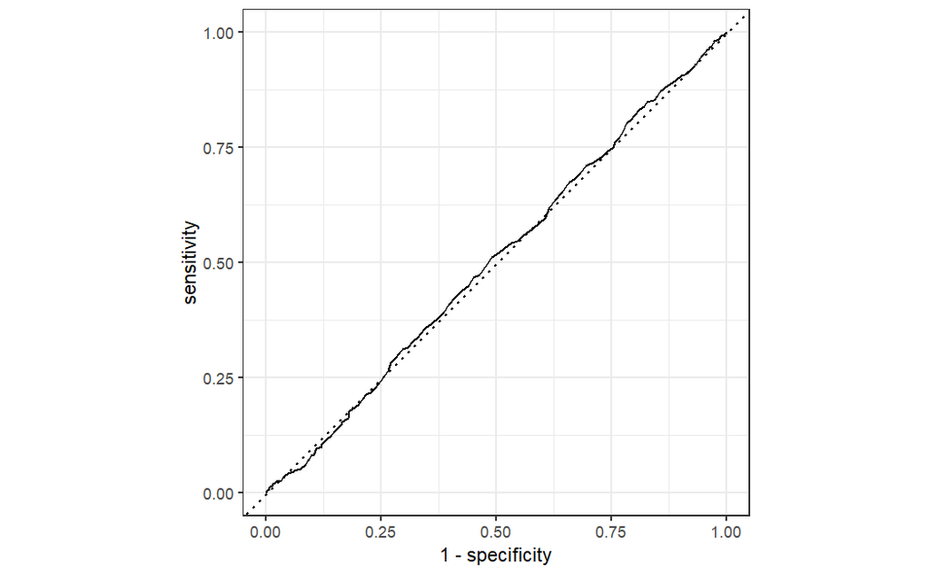

```r
autoplot(rf_curve)
```

```r
roc_auc(rf_roc, Outcome, AtRisk)
```

| .metric | .estimator | .estimate |
| --- | --- | --- |
| roc_auc | binary | 0.5039629 |

```r
importance(mod.rf)
```

```
                                     AtRisk  NotatRisk MeanDecreaseAccuracy MeanDecreaseGini
Age                              1.45160848  1.4711876            2.0075940        336.97326
Sex                              0.00000000  0.0000000            0.0000000          0.00000
Cholesterol                      0.02929013  0.9980400            0.8936252        373.35893
Diet                            -0.64313555  1.1231483            0.5468419         98.39845
Heart.Rate                      -0.34518104  2.2612181            1.5736391        341.30779
Diabetes                         0.66238299  1.7443807            1.8626871         52.79037
Family.History                  -1.74251380  0.6092819           -0.5600794         57.54262
Smoking                         -2.59370812  2.4705044            0.5929161         28.84468
Obesity                         -0.80369806  1.0325864            0.3819980         59.07047
Exercise.Hours.Per.Week         -1.65038923 -1.3726412           -2.1381577        396.02661
Previous.Heart.Problems         -0.22615002 -0.8245647           -0.7904547         57.92230
Medication.Use                  -2.99575490 -0.3227272           -2.2467924         56.71658
Stress.Level                    -1.40304302 -1.8002244           -2.1475502        209.29117
BMI                              0.28034494  0.4048552            0.5143967        396.64318
Triglycerides                    0.27314958  1.2670449            1.2575753        388.38829
Physical.Activity.Days.Per.Week -1.76560638  0.4397826           -0.6725424        186.38197
Sleep.Hours.Per.Day              0.91555722  0.6681825            1.1057392        164.05558
```

DECISION TREES

```r
mod.dt = rpart(Outcome ~ Age + Sex + Cholesterol + Diet + Heart.Rate + Diabetes + Family.History + Smoking + Obesity + Exercise.Hours.Per.Week + Previous.Heart.Problems + Medication.Use + Stress.Level + BMI + Triglycerides + Physical.Activity.Days.Per.Week + Sleep.Hours.Per.Day,data = train, na.action = na.omit)
```

```r
dt.test = test %>%
  mutate(Prediction = predict(mod.dt, test, type="class"))
glimpse(dt.test)
```

```
Rows: 1,753
Columns: 28
$ Patient.ID                      <chr> "CZE1114", "BNI9906", "XXM0972", "FPS0415", "YYU9565", "VTW9069", "DCY3282", "RVN496…
$ Age                             <int> 21, 21, 84, 77, 60, 88, 73, 45, 90, 79, 86, 67, 29, 51, 70, 85, 67, 31, 24, 26, 31, …
$ Sex                             <dbl> 0, 0, 0, 0, 0, 0, 0, 0, 0, 0, 0, 0, 0, 0, 0, 0, 0, 0, 0, 0, 0, 0, 0, 0, 0, 0, 0, 0, …
$ Cholesterol                     <int> 389, 324, 220, 228, 259, 297, 122, 294, 159, 328, 375, 347, 129, 197, 279, 336, 222,…
$ Blood.Pressure                  <chr> "165/93", "174/99", "131/68", "101/72", "169/72", "112/81", "114/88", "130/84", "140…
$ Heart.Rate                      <int> 98, 72, 107, 68, 85, 102, 97, 66, 52, 74, 46, 65, 86, 79, 86, 73, 105, 92, 68, 46, 4…
$ Diabetes                        <int> 1, 1, 0, 1, 1, 1, 1, 0, 0, 0, 1, 1, 0, 1, 0, 1, 1, 1, 0, 1, 1, 1, 0, 1, 0, 1, 1, 1, …
$ Family.History                  <int> 1, 0, 0, 1, 1, 1, 1, 0, 0, 0, 1, 0, 1, 1, 0, 1, 1, 1, 1, 0, 0, 0, 1, 0, 0, 0, 1, 0, …
$ Smoking                         <int> 1, 0, 1, 1, 1, 1, 1, 1, 1, 1, 1, 1, 1, 1, 1, 1, 1, 1, 1, 1, 0, 1, 0, 1, 1, 1, 1, 1, …
$ Obesity                         <int> 1, 0, 1, 1, 0, 0, 0, 1, 0, 0, 0, 1, 1, 1, 1, 0, 1, 1, 1, 0, 1, 0, 0, 0, 0, 1, 1, 0, …
$ Alcohol.Consumption             <int> 1, 0, 1, 1, 1, 1, 1, 1, 1, 1, 0, 1, 1, 0, 1, 1, 0, 1, 1, 1, 0, 1, 0, 1, 1, 1, 0, 0, …
$ Exercise.Hours.Per.Week         <dbl> 1.8132416, 2.0783530, 3.4279288, 19.6332682, 17.0373742, 15.3876046, 14.5596645, 13.…
$ Diet                            <fct> Unhealthy, Healthy, Average, Unhealthy, Healthy, Unhealthy, Average, Healthy, Health…
$ Previous.Heart.Problems         <int> 1, 1, 0, 0, 1, 0, 0, 0, 0, 0, 0, 1, 1, 0, 1, 0, 1, 0, 0, 0, 0, 0, 0, 0, 1, 0, 1, 0, …
$ Medication.Use                  <int> 0, 1, 1, 0, 1, 1, 0, 0, 1, 0, 1, 0, 1, 0, 1, 1, 1, 1, 1, 0, 0, 1, 1, 1, 0, 0, 1, 0, …
$ Stress.Level                    <int> 1, 9, 4, 9, 1, 2, 5, 9, 2, 1, 3, 1, 3, 3, 6, 1, 1, 2, 10, 3, 5, 2, 6, 2, 4, 6, 3, 9,…
$ Sedentary.Hours.Per.Day         <dbl> 4.9634588, 9.4634258, 10.5437802, 10.9175243, 8.7274172, 10.4254896, 10.0864790, 7.0…
$ Income                          <int> 285768, 235282, 122093, 29886, 292173, 165300, 265839, 216565, 110213, 98663, 163789…
$ BMI                             <dbl> 27.19497, 28.17657, 22.22186, 35.10224, 25.56490, 25.49174, 36.52440, 25.12060, 26.0…
$ Triglycerides                   <int> 235, 587, 370, 590, 506, 635, 773, 360, 667, 482, 209, 790, 697, 785, 792, 584, 92, …
$ Physical.Activity.Days.Per.Week <int> 1, 4, 6, 7, 1, 3, 5, 4, 4, 4, 6, 1, 4, 1, 4, 7, 0, 7, 3, 7, 5, 1, 3, 4, 0, 7, 3, 2, …
$ Sleep.Hours.Per.Day             <int> 7, 4, 7, 6, 4, 6, 8, 6, 5, 6, 10, 10, 6, 5, 6, 10, 8, 9, 8, 5, 6, 9, 5, 6, 10, 4, 5,…
$ Country                         <fct> Canada, France, Japan, Vietnam, China, China, Italy, France, Spain, China, France, I…
$ Continent                       <fct> North America, Europe, Asia, Asia, Asia, Asia, Europe, Europe, Europe, Asia, Europe,…
$ Hemisphere                      <fct> Northern Hemisphere, Northern Hemisphere, Northern Hemisphere, Northern Hemisphere, …
$ Heart.Attack.Risk               <int> 0, 0, 1, 1, 1, 0, 1, 1, 0, 0, 0, 0, 0, 0, 1, 0, 0, 0, 0, 1, 0, 1, 0, 1, 0, 0, 1, 1, …
$ Outcome                         <fct> NotatRisk, NotatRisk, AtRisk, AtRisk, AtRisk, NotatRisk, AtRisk, AtRisk, NotatRisk, …
$ Prediction                      <fct> NotatRisk, NotatRisk, NotatRisk, NotatRisk, NotatRisk, NotatRisk, NotatRisk, NotatRi…
```

```r
metrics = metric_set(accuracy, precision, sensitivity, specificity)
metrics(dt.test, truth=Outcome, estimate=Prediction, na_rm = TRUE)
```

| .metric | .estimator | .estimate |
| --- | --- | --- |
| accuracy | binary | 0.6286366 |
| precision | binary | NA |
| sensitivity | binary | 0.0000000 |
| specificity | binary | 1.0000000 |

ROC Curve and AUC…

```r
dt_roc = predict(mod.dt, test, type="prob") %>%
  as_tibble() %>%
  mutate(diff= NotatRisk - AtRisk,
         logratio=log(NotatRisk) - log(AtRisk),
         pred=if_else(NotatRisk > AtRisk, "NotatRisk", "AtRisk")) %>%
  mutate(Outcome=rf.test$Outcome)
dt_roc
```

| AtRisk | NotatRisk | diff | logratio | pred | Outcome |
| --- | --- | --- | --- | --- | --- |
| 0.3549215 | 0.6450785 | 0.2901569 | 0.5974752 | NotatRisk | NotatRisk |
| 0.3549215 | 0.6450785 | 0.2901569 | 0.5974752 | NotatRisk | NotatRisk |
| 0.3549215 | 0.6450785 | 0.2901569 | 0.5974752 | NotatRisk | AtRisk |
| 0.3549215 | 0.6450785 | 0.2901569 | 0.5974752 | NotatRisk | AtRisk |
| 0.3549215 | 0.6450785 | 0.2901569 | 0.5974752 | NotatRisk | AtRisk |
| 0.3549215 | 0.6450785 | 0.2901569 | 0.5974752 | NotatRisk | NotatRisk |
| 0.3549215 | 0.6450785 | 0.2901569 | 0.5974752 | NotatRisk | AtRisk |
| 0.3549215 | 0.6450785 | 0.2901569 | 0.5974752 | NotatRisk | AtRisk |
| 0.3549215 | 0.6450785 | 0.2901569 | 0.5974752 | NotatRisk | NotatRisk |
| 0.3549215 | 0.6450785 | 0.2901569 | 0.5974752 | NotatRisk | NotatRisk |

[output cut: 990 more lines]

```r
dt_curve = roc_curve(dt_roc, Outcome, AtRisk)
glimpse(dt_curve)
```

```
Rows: 3
Columns: 3
$ .threshold  <dbl> -Inf, 0.3549215, Inf
$ specificity <dbl> 0, 0, 1
$ sensitivity <dbl> 1, 1, 0
```

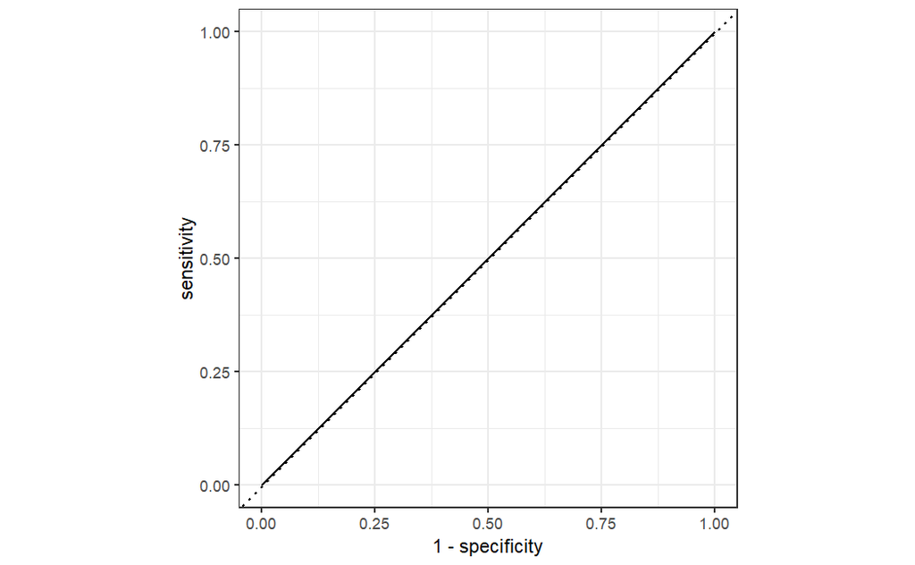

```r
autoplot(dt_curve)
```

```r
roc_auc(dt_roc, Outcome, AtRisk)
```

| .metric | .estimator | .estimate |
| --- | --- | --- |
| roc_auc | binary | 0.5 |